# Practica 2 — Procesamiento Digital de Imagenes

**Alumno:** Fernando Leon Franco **Fecha de entrega:** 6 de abril de 2026

## Resumen

En esta practica se aplican tecnicas de transformaciones lineales y procesamiento basado en histograma para resolver distintos problemas sobre imagenes digitales. Se trabaja con radiografias, fotografias de camaras industriales, imagenes escaneadas, fotografias a color y en blanco y negro.

Las tecnicas utilizadas a lo largo de la practica son: ganancia digital, transformacion gamma ($s = r^{\gamma}$), negativo, transformacion lineal por tramos, ecualizacion de histograma y remapeo por canal para falso color. Cada ejercicio parte de analizar el histograma de la imagen original para entender donde se concentran los pixeles y con base en eso decidir que transformacion aplicar. Se comparan los resultados tanto visualmente como a traves de los histogramas antes y despues del procesamiento.

```python
%matplotlib inline
import sys
from pathlib import Path
import matplotlib.pyplot as plt

BASE_DIR = Path().resolve().parents[1]
sys.path.insert(0, str(BASE_DIR))

from image_processing.ajustes_dinamicos import DynamicVisionNode

DATA_DIR = BASE_DIR / "image_processing" / "practica" / "data"

files = {
    "korda":       "korda.jpg",
    "torax":       "toraxP.bmp",
    "laboratorio": "laboratorio.bmp",
    "grafica":     "GRAFICA2.bmp",
    "tumba":       "tumba.bmp",
    "austin":      "austincolor.jpg",
    "cheyenne":    "CheyenneMWIR.jpg",
    "cuadros":    "cuadros_gris.bmp",
}

def load_image(nombre: str) -> DynamicVisionNode:
    return DynamicVisionNode.desde_archivo(DATA_DIR / files[nombre])
```

## 1️⃣ A — Ejercicio 1a

Una radiografía fue tomada para diagnosticar en un paciente problemas en la columna vertebral. Por un error del operador de la máquina de rayos X, los huesos no aparecen de manera clara. Como el paciente no puede ser expuesto nuevamente, debido a que ya se ha tomado demasiadas radiografías para un año, se le pide a usted que procese dicha radiografía para mejorar la definición de los huesos. Explique cómo seleccionó el procesamiento aplicado.

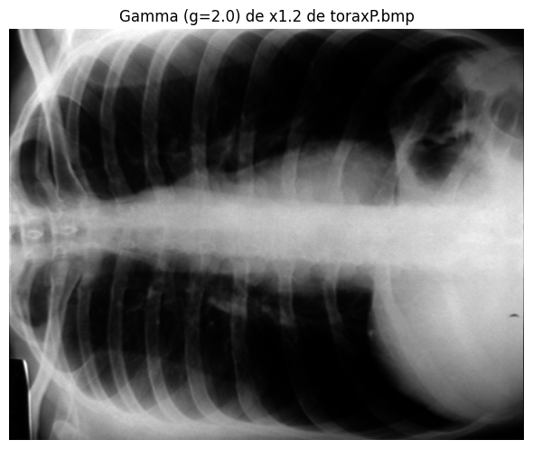

```python
imagen_torax = load_image("torax")
imagen_torax.mostrar(block=False)

img_ganancia = imagen_torax.ganancia(1.2)

# Solo gama
img_tranform = img_ganancia.transformacion_gamma(2.0)
img_tranform.mostrar(block=False)

plt.show()
```

### Explicaciones del Ejercicio 1a

**Descripción:** Se tiene una radiografía de tórax donde los huesos no se ven con claridad por un error del operador. El objetivo es mejorar la definición de los huesos sin volver a exponer al paciente. Se aplicó una ganancia de 1.2 y después una transformación gamma con $\gamma = 2.0$.

**Explicación:** La ganancia multiplica el valor de cada píxel por un factor constante, en este caso 1.2. Si un píxel tenía un valor de 100, ahora pasa a tener 120. Esto aumenta un poco el brillo general y ya empieza a separar los niveles de intensidad entre los huesos y el fondo.

La transformación gamma aplica la función:

$$s = r^{\gamma}$$

donde $r$ es el valor normalizado del píxel (entre 0 y 1). Con $\gamma = 2.0$, los valores claros (donde están los huesos) se separan más entre sí, mientras que los oscuros se comprimen. Al combinar las dos operaciones, las costillas cercanas a la cadera que antes se fundían con el fondo blanco ahora se alcanzan a definir mejor. No se buscaba algo extremo, simplemente que las estructuras óseas fueran más distinguibles.

## 1️⃣ B — Ejercicio 1b

Una vez que ha regresado el paciente con su radiografía al consultorio, el médico sospecha de problemas en el pulmón y el hígado al enterarse que el paciente consume alcohol y tabaco en cantidades no recomendables. ¿Podría usted mejorar la radiografía para facilitar el diagnóstico en este caso? Explique cómo seleccionó el procesamiento aplicado.

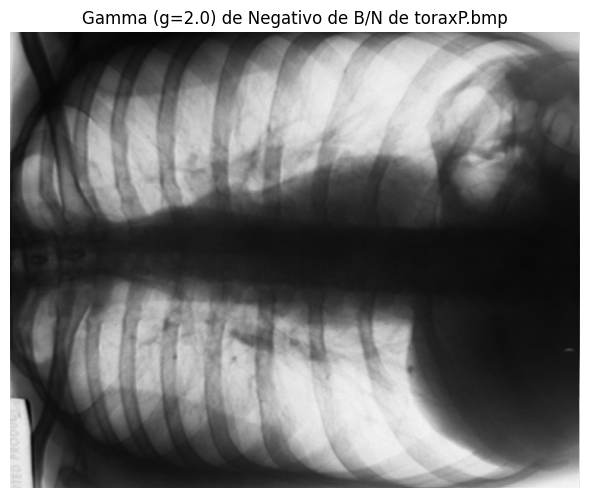

```python
imagen_torax = load_image("torax")
imagen_torax.mostrar(block=False)

img_negativo = (
    imagen_torax
    .escala_grises()
    .negativo()
    .transformacion_gamma(2.0)
)
img_negativo.mostrar(block=False)

plt.show()
```

### Explicaciones del Ejercicio 1b

**Descripción:** Se carga la imagen de la radiografía, se convierte a escala de grises, se aplica un negativo y finalmente una transformación gamma con $\gamma = 2.0$.

**¿Pudiste mejorar la radiografía para facilitar el diagnóstico?**

Sí, sin duda. La mejora es bastante notoria.

**¿Cómo seleccionaste el procesamiento aplicado?**

La radiografía original está hecha para ver huesos: la radiación pasa por el tejido blando y se marca donde incide en los huesos y tejidos con más masa. Sin embargo, en la imagen original ya se alcanzan a distinguir algunas estructuras como los alvéolos, lo que parece ser el corazón y el hígado, que aparecen como manchas blancas.

Para poder ver mejor esos tejidos blandos, primero se convirtió a escala de grises para unificar los canales. Esto es necesario porque el siguiente paso es aplicar un negativo, es decir, restar la imagen para obtener lo contrario:

$$s = 1 - r$$

De esta forma, en vez de tener brillo en los huesos, ahora las zonas que eran oscuras (tejidos blandos) se vuelven brillosas y las que eran brillosas (huesos) se vuelven oscuras. Esto invierte la imagen y nos permite ver cómo están los tejidos blandos.

Después se aplica la transformación gamma con $\gamma = 2.0$. Recordemos que este ajuste vuelve las zonas oscuras un poco más oscuras, lo cual nos ayuda a remarcar justamente lo que buscamos: poder ver daños en el hígado o en los pulmones, que es lo que el médico sospecha.

## 1️⃣ C — Ejercicio 1c

Después de discutir sus malos hábitos, el paciente comenta de cierto dolor en la articulación de la cadera, justo en la parte alta de la pierna derecha. Mejore la imagen de tal forma que sea mas clara esta articulación. Explique cómo seleccionó el procesamiento aplicado.

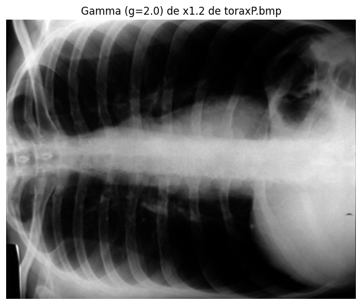

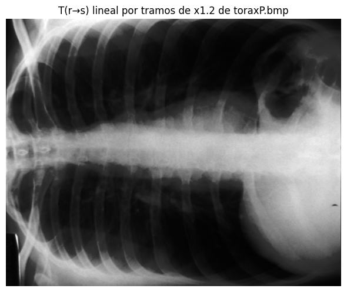

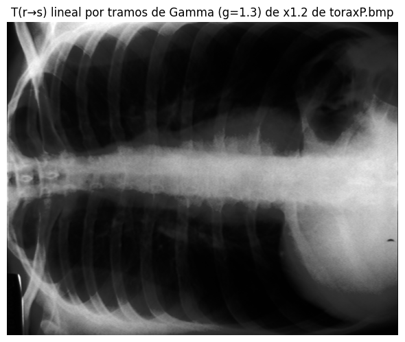

```python
imagen_torax = load_image("torax")
imagen_torax.mostrar(block=False)

img_ganancia = imagen_torax.ganancia(1.2)

# Solo gama
img_tranform = img_ganancia.transformacion_gamma(2.0)
img_tranform.mostrar(block=False)

entrada = (0, 149, 150, 255)
salida  = (0,  50,  50, 255)

img_linear = img_ganancia.transformacion_lineal(entrada=entrada, salida=salida)
img_linear.mostrar(block=False)

# Gama + lineal
gama_mas_linear = (
    img_ganancia
    .transformacion_gamma(1.3)
    .transformacion_lineal(entrada=entrada, salida=salida)
)
gama_mas_linear.mostrar(block=False)

plt.show()
```

### Explicaciones del Ejercicio 1c

**Descripción:** Se busca mejorar la visibilidad de la articulación de la cadera. Para ello se generaron tres muestras diferentes, todas partiendo de una ganancia de 1.2:

1. Solo transformación gamma con $\gamma = 2.0$
2. Solo transformación lineal con entrada $(0, 149, 150, 255)$ y salida $(0, 50, 50, 255)$
3. Transformación gamma con $\gamma = 1.3$ seguida de la misma transformación lineal

**¿Cómo seleccionaste el procesamiento para mejorar la articulación de la cadera?**

El parámetro que nos autoimpusimos para evaluar cada método fue contar cuántas vértebras de la columna se alcanzaban a distinguir. Si podíamos ver bien las vértebras, entonces el hueso de la cadera también sería visible.

En la imagen original apenas se distinguían unas 5 vértebras. Con la primera muestra (solo gamma), se mejoró y se alcanzaban a ver unas 7, pero no era suficiente. Con la segunda muestra (transformación lineal), se alcanzaron a distinguir 9 vértebras sin problema. Y con la tercera muestra (gamma 1.3 + lineal), se lograron ver 10 y casi 11 vértebras.

La transformación lineal funciona como un mapeo: toma una sección de los píxeles y los empuja hacia valores de salida definidos. En este caso, los valores de entrada $(0, 149, 150, 255)$ se mapean a $(0, 50, 50, 255)$, lo que fuerza a que los píxeles en cierto rango se redistribuyan y se gane contraste en las zonas que nos interesan.

En la tercera muestra se usó una gamma menor ($\gamma = 1.3$) solo para resaltar un poco las zonas oscuras, y luego la transformación lineal se encargó de empujar los píxeles que la gamma por sí sola no alcanzaba a mejorar. Esa combinación fue la que dio el mejor resultado: el hueso de la cadera se distingue con claridad y las vértebras se ven bien definidas.

## 2️⃣ — Ejercicio 2

La imagen laboratorio.bmp fue tomada usando una cámara digital industrial (Genie Nano de Dalsa Teledyne). Sin embargo, la apariencia no es agradable (regiones muy obscuras) y no se parece a la fotografía que obtendría con un teléfono celular. Explique por que esta fotografía no se ve como una fotografía de cámara de consumidor. Arregle la fotografía para obtener una mejor apariencia.

[figure not shown]

[figure not shown]

[figure not shown]

```python
imagen_laboratorio = load_image("laboratorio")
imagen_laboratorio.histograma(block=False)

img_tranform = imagen_laboratorio.transformacion_gamma(.5)
img_tranform.histograma(block=False)

img_acomuladp = (
    imagen_laboratorio
    .transformacion_gamma(0.5)
    .ecualizar()
)
img_acomuladp.histograma(block=False)

plt.show()
```

### Explicaciones del Ejercicio 2

**Descripción:** Se carga la imagen del laboratorio tomada con una cámara industrial (Genie Nano de Dalsa Teledyne). Se aplica una transformación gamma con $\gamma = 0.5$ y también se prueba combinar gamma con ecualización de histograma.

**¿Por qué esta fotografía no se ve como una fotografía de cámara de consumidor?**

Porque una cámara de consumidor (como un celular) automáticamente ecualiza y ajusta muchos valores de brillo y contraste para que la imagen se vea agradable. Una cámara industrial no hace esto, entrega la imagen cruda tal como la captura el sensor, lo que resulta en regiones muy oscuras. De hecho, el histograma original muestra que la mayoría de los píxeles en los tres canales se concentran entre 0 y 50, es decir, casi todo está en tonos muy oscuros.

**¿Qué procesamiento aplicaste para mejorar su apariencia y por qué?**

Se aplicó una transformación gamma con $\gamma = 0.5$. Cuando $\gamma < 1$, la función $s = r^{\gamma}$ hace que los valores oscuros se vuelvan más brillosos, que es justamente lo que necesitábamos. Con este ajuste, los píxeles se recorren: ya casi no hay píxeles entre 0 y 25, y la mayor concentración pasa a estar entre 25 y 100. La imagen se ve mucho mejor.

Según nota del profesor, las cámaras industriales suelen ajustarse con una gamma de alrededor de 0.6, así que con 0.5 estábamos muy cerca de ese valor.

También se probó combinar gamma con ecualización de histograma. Aunque la imagen mejoró y se ve bien, en muchas zonas los píxeles se fundieron, así que no necesariamente se obtuvo un mejor resultado que con solo gamma. La ecualización tiende a forzar una distribución uniforme y eso puede perder detalle en algunas zonas.

## 3️⃣ — Ejercicio 3

Su profesor de Procesamiento Digital de Imágenes presume que él mismo ha dibujado las gráficas que presentó en la clase introductoria (grafica2.bmp). Usted sospecha que en realidad se trata de un plagio del libro de texto (Capítulo 4.2.1, Algunas transformaciones de intensidad simples, negativos de imágenes). Pruebe de manera convincente su hipótesis.

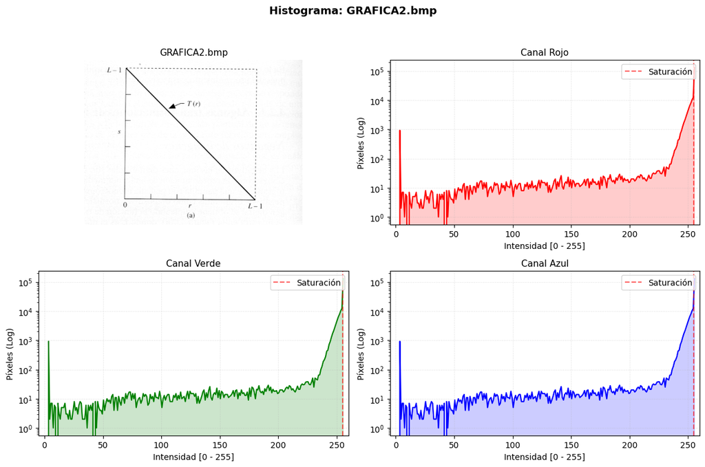

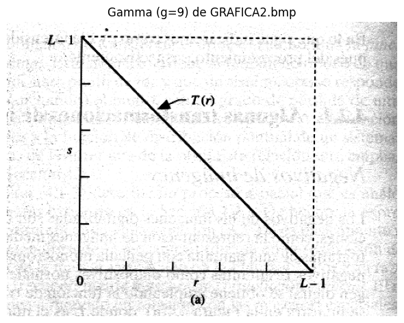

```
<image_processing.ajustes_dinamicos.DynamicVisionNode at 0x11200adb0>
```

```python
imagen_grafica = load_image("grafica")
imagen_grafica.histograma(block=False)

gama = imagen_grafica.transformacion_gamma(9)
gama.mostrar(block=False)
```

### Explicaciones del Ejercicio 3

**Descripción:** Se tiene la imagen grafica2.bmp que el profesor dice haber dibujado él mismo. Se sospecha que en realidad es un escaneo o fotocopia de un libro de texto. Se aplicó una transformación gamma con $\gamma = 9$ para probarlo.

**¿Cómo probaste de manera convincente que se trata de un plagio?**

Viendo el histograma, la mayoría de los píxeles están cargados hacia el blanco, lo cual tiene sentido porque es una imagen de gráficas sobre fondo blanco. Pero si fuera una imagen genuina digital, el fondo sería blanco puro (255) y no tendría variaciones.

La pista es que si viene de un libro, las zonas "blancas" en realidad no son perfectamente blancas: tienen pequeños píxeles oscuros imperceptibles para el ojo humano, como el texto del reverso de la página que se alcanza a filtrar o artefactos propios de una fotocopiadora o escáner.

Al aplicar una gamma de $\gamma = 9$, la función $s = r^{9}$ hace que cualquier valor que no sea exactamente 1.0 (blanco puro) caiga dramáticamente hacia el negro. Esto exagera y hace visibles esas pequeñísimas diferencias. El resultado muestra claramente fragmentos de texto del reverso del libro y artefactos que solo presentaría una fotocopia, no una imagen dibujada digitalmente. Podría haberse usado otro valor de gamma, pero con 9 fue más que suficiente para demostrarlo.

## 4️⃣ — Ejercicio 4

Tenemos la imagen tumba.bmp donde el mármol aparece muy claro y el fondo demasiado obscuro. Pruebe si puede arreglar esta imagen aplicando simplemente ganancia digital. ¿Qué resultados obtiene? Explique usando el histograma.

[figure not shown]

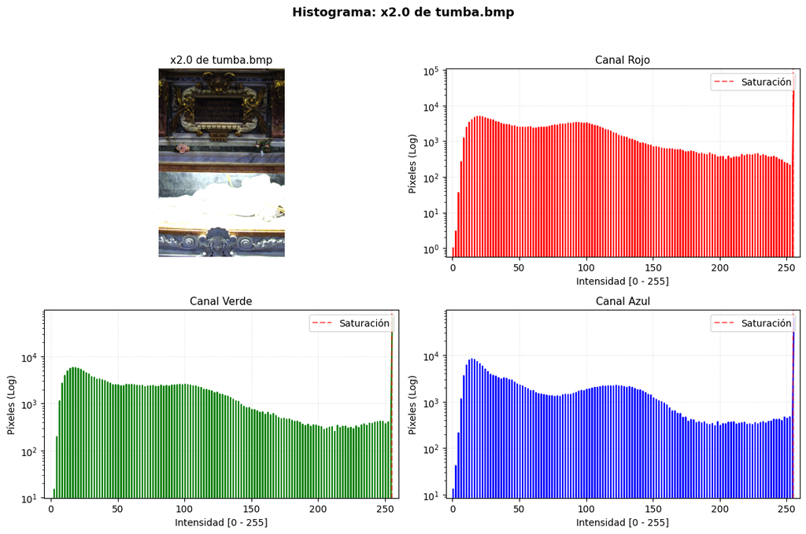

```python
imagen_tumba = load_image("tumba")
imagen_tumba.histograma(block=False)

img_ganancia = imagen_tumba.ganancia(2.0)
img_ganancia.histograma(block=False)

plt.show()
```

### Explicaciones del Ejercicio 4

**Descripción:** Se tiene la imagen tumba.bmp donde hay una estatua de mármol blanco y una lápida bastante oscura. Se aplica una ganancia de 2.0 y se analiza el resultado con el histograma.

**¿Qué resultados obtuviste al aplicar ganancia digital?**

Sí se mejoró la imagen. La ganancia de 2 multiplica todos los píxeles por 2, lo cual aclara las zonas oscuras de la lápida y permite ver más detalle ahí. Sin embargo, como la ganancia afecta a todos los píxeles por igual, los que ya eran blancos (el mármol) se vuelven aún más blancos y se funden hacia el blanco puro. Entonces se gana detalle en las zonas oscuras pero se pierde en las zonas claras.

**Explica el efecto observado usando el histograma:**

En el histograma original se ve que la imagen tiene un buen balance general, pero hay una concentración de píxeles en los extremos: muchos píxeles oscuros (la lápida) y muchos píxeles claros (el mármol). Los rojos tienen un poco más de concentración de píxeles que los otros canales.

Al aplicar la ganancia de 2, el histograma muestra cómo las crestas donde se concentraban los píxeles se suavizan y se recorren hacia la derecha. Las zonas oscuras ahora tienen valores más repartidos, lo cual se ve como mejor detalle. Pero también se ve claramente cómo los píxeles claros se saturan y se acumulan en 255 (blanco puro), que es justamente el efecto de fundirse en blanco que se observa en la imagen.

## 5️⃣ — Ejercicio 5

Considere la misma imagen tumba.bmp. Esta es una imagen a color, pero comenzaremos con procesamiento en blanco y negro. Queremos mejor visibilidad en las zonas obscuras y mejor contraste en las zonas de mármol blanco. Defina a mano una función de transformación T para mejorar esta imagen. Explique el criterio para definir esta función. Después pruebe usando ajuste de gama y busque si puede lograr un mejor resultado. Finalmente intente con ecualización de imagen. Reporte y compare las tres funciones de transformación. ¿Cuáles son las diferencias que encontró entre las funciones y sus resultados?

[figure not shown]

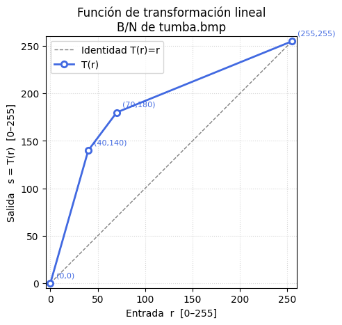

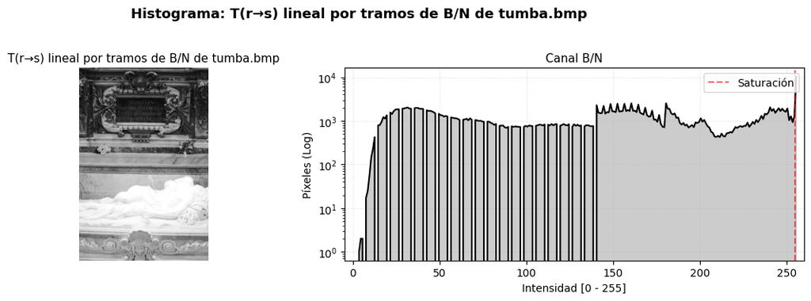

[figure not shown]

[figure not shown]

```python
imagen_tumba = load_image("tumba")
imagen_b_n = imagen_tumba.escala_grises()
imagen_b_n.histograma(block=False)

# Transformación Lineal
entrada = (0, 40, 70, 255)
salida  = (0, 140, 180, 255)

img_linear = imagen_b_n.transformacion_lineal(entrada=entrada, salida=salida, show_transform=True)
img_linear.histograma(block=False)

# Transformación Gamma
img_gamma = imagen_b_n.transformacion_gamma(0.5)
img_gamma.histograma(block=False)

# Ecualización
img_ecualizacion = imagen_b_n.ecualizar()
img_ecualizacion.histograma(block=False)

plt.show()
```

### Explicaciones del Ejercicio 5

**Descripción:** Se trabaja con la imagen tumba.bmp convertida a escala de grises. Se aplican tres métodos diferentes para mejorar la visibilidad de las zonas oscuras y el contraste del mármol blanco: transformación lineal por tramos, transformación gamma con $\gamma = 0.5$ y ecualización de histograma.

**¿Cuál fue el criterio para definir la función de transformación T lineal por tramos?**

Al convertir a escala de grises y ver el histograma, se nota que antes de los 70 píxeles hay una concentración significativa: el logaritmo de píxeles está por arriba de $10^3$ en esa zona. En cambio, desde los 70 hasta los 250 aproximadamente, la cantidad de píxeles cae por debajo de $10^3$. Eso significa que la mayoría de la información está acumulada en las zonas oscuras.

Con base en eso se definieron las entradas $(0, 40, 70, 255)$ y salidas $(0, 140, 180, 255)$, que básicamente elevan los píxeles de 40 a 140 y de 70 a 180. Esto ataca justo donde está la acumulación y la imagen mejoró muchísimo, realzando los detalles de la lápida. Es un enfoque artesanal: se segmenta el histograma, se identifica dónde están los píxeles y se ataca ahí. Aunque estuvo muy bien, hay que reconocer que los blancos se fundieron bastante.

**¿El ajuste de gama logró un mejor resultado? ¿Por qué?**

Sí, definitivamente. Con $\gamma = 0.5$ se aclaran las zonas oscuras y el histograma se recorre: los píxeles que estaban acumulados antes de 70 ahora se reparten, y a partir de los 40 se empieza a ver una distribución más pareja que se mantiene por arriba de $10^3$ hasta aproximadamente el píxel 120 o 130. El histograma se centralizó más. La transformación gamma es más equitativa porque aplica la misma función a todos los píxeles, sin necesidad de definir puntos a mano.

**Compara las tres funciones (T lineal, gamma, ecualización): ¿cuáles son las diferencias entre ellas y sus resultados?**

La **lineal** es la más artesanal: permite atacar zonas específicas del histograma, pero requiere definir los puntos manualmente y en este caso los blancos se fundieron bastante. La **gamma** aplicó una transformación equitativa que recorrió el histograma de forma pareja, con muy buen resultado sin necesidad de segmentar. La **ecualización** comprimió mucho más: la estatua blanca se ve un poco más gris y se alcanzan a notar más formas y contornos, mientras que la tumba se aclaró mucho. El ecualizado se siente muy bien porque la imagen se acopla a lo que se necesita sin distorsionarse, ya que fuerza a que el canal se ajuste a una distribución más uniforme.

## 6️⃣ — Ejercicio 6

Repita el proceso anterior, pero procesando en color. ¿Qué resultados obtuvo? ¿Hay cambios significativos en el color aparente? ¿Cómo es diferente el procesamiento en color al procesamiento en blanco y negro?

[figure not shown]

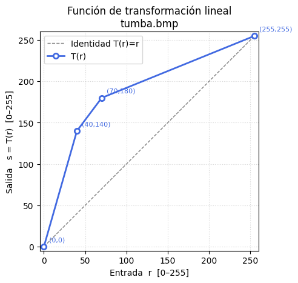

[figure not shown]

[figure not shown]

[figure not shown]

```python
imagen_tumba = load_image("tumba")
imagen_tumba.histograma(block=False)

# Transformación Lineal
entrada = (0, 40, 70, 255)
salida  = (0, 140, 180, 255)

img_linear = imagen_tumba.transformacion_lineal(entrada=entrada, salida=salida, show_transform=True)
img_linear.histograma(block=False)

# Transformación Gamma
img_gamma = imagen_tumba.transformacion_gamma(0.5)
img_gamma.histograma(block=False)

# Ecualización
img_ecualizacion = imagen_tumba.ecualizar()
img_ecualizacion.histograma(block=False)

plt.show()
```

### Explicaciones del Ejercicio 6

**Descripción:** Se repite el mismo proceso del ejercicio 5 (transformación lineal, gamma y ecualización) pero ahora trabajando con la imagen a color, es decir, con los tres canales RGB por separado.

**¿Qué resultados obtuviste al procesar en color?**

La transformación lineal funciona muy bien: los colores se mantienen, simplemente se mejoran. Considero que es una de las mejores opciones. La gamma con $\gamma = 0.5$ hace que la imagen se vea un poco más opaca. Basándonos en el histograma, se siente que la transformación lineal separa y acota mejor los píxeles que la gamma, aunque eso ya es a percepción de cada quien.

La ecualización tiene un problema grande: modifica los colores de manera exagerada. Los tonos se ven raros y no son muy reales comparados con el original.

**¿Hay cambios significativos en el color aparente?**

Con la transformación lineal y la gamma no tanto, los colores se mantienen relativamente fieles. Pero con la ecualización sí hay cambios muy notorios en los tonos de color.

**¿Cómo es diferente el procesamiento en color al procesamiento en blanco y negro?**

La diferencia principal es que en color se trabaja con tres canales (rojo, verde y azul) de manera independiente. En blanco y negro solo hay un canal y cualquier transformación se aplica directamente sin problema. Pero en color, al modificar cada canal por separado, se afecta la relación entre ellos, lo cual puede alterar los colores resultantes.

Esto se nota especialmente con la ecualización: aunque se aplica el ecualizado por canal (gracias a PyTorch), al modificar de manera independiente cada canal, el balance de color original se pierde y los tonos se distorsionan mucho. Un compañero mencionó que lo ideal sería afectar un cuarto canal de brillo (luminancia) en vez de tocar directamente el rojo, verde y azul, pero en esta ocasión se aplicó directamente sobre cada canal de color.

## 7️⃣ — Ejercicio 7

Genere los vectores de remapeo Tr, Tg y Tb para falso color, tales que una imagen en infrarrojo presente la apariencia de la fotografía AUSTINCOLOR.JPG. Reporte cómo llegó a su definición de las funciones de transformación Tr, Tg y Tb.

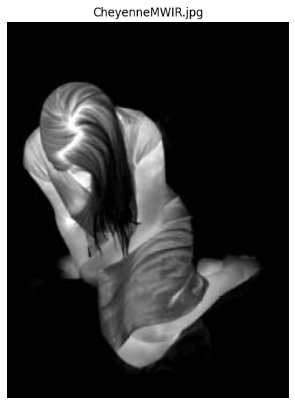

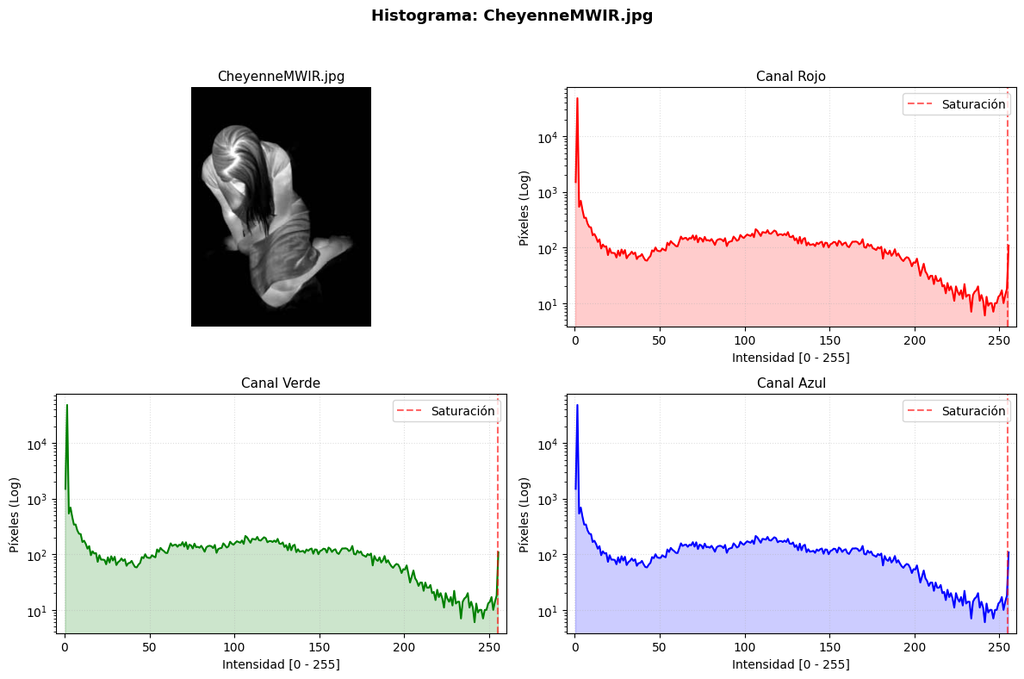

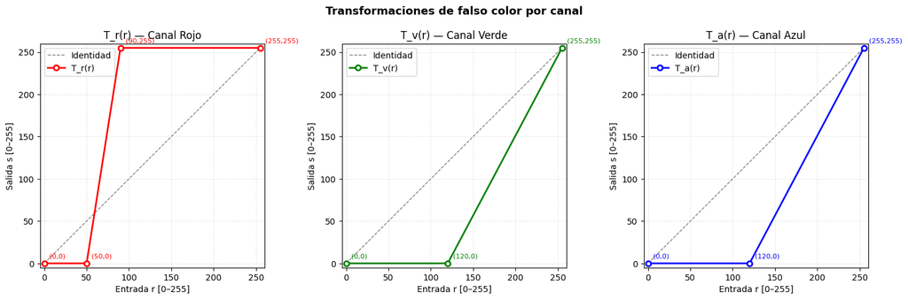

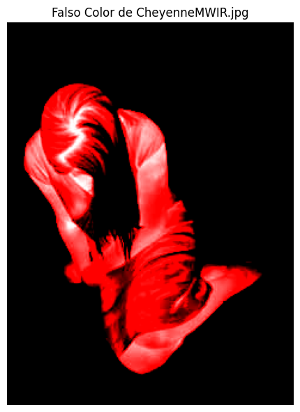

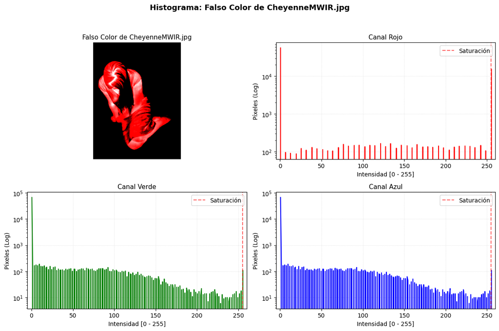

```python
imagen_cheyenne = load_image("cheyenne")
imagen_cheyenne.mostrar(block=False)
imagen_cheyenne.histograma(block=False)


Tred = (
    (0,   0),
    (50,   0),
    (90,   255),
    (255, 255),
)
Tgreen = (
    (0,   0),
    (120,   0),
    (255, 255),
)
Tblue = (
    (0,   0),
    (120,   0),
    (255, 255),
)

img_falso_color = imagen_cheyenne.transformacion_lineal_por_canal(Tred, Tgreen, Tblue)
img_falso_color.histograma(block=False)

plt.show()
```

### Explicaciones del Ejercicio 7

**Descripción:** Se genera un falso color sobre la imagen infrarroja CheyenneMWIR.jpg, definiendo vectores de remapeo $T_r$, $T_g$ y $T_b$ para cada canal, buscando que la imagen presente una apariencia similar a la fotografía AUSTINCOLOR.JPG.

Las transformaciones definidas fueron:

- $T_{red}$: $(0, 0) \rightarrow (50, 0) \rightarrow (90, 255) \rightarrow (255, 255)$
- $T_{green}$: $(0, 0) \rightarrow (120, 0) \rightarrow (255, 255)$
- $T_{blue}$: $(0, 0) \rightarrow (120, 0) \rightarrow (255, 255)$

Es decir, el rojo se mantiene en 0 hasta el píxel 50 y sube a 255 en el píxel 90, manteniéndose ahí hasta el final. El verde y el azul se mantienen en 0 hasta el píxel 120 y suben a 255 hasta el final.

**¿Cómo llegaste a la definición de Tr, Tg y Tb?**

Fue a prueba y error. Un buen tip del profesor fue primero usar una imagen de cuadros de grises (segmentos desde el negro hasta el blanco en cada esquina, pasando por tonalidades de gris). Esto permitió entender cómo va transformando cada canal antes de tocar la imagen original.

La idea es que los píxeles más oscuros (zonas frías del infrarrojo) se deben ver negros, por lo cual todos los canales arrancan en 0. Conforme subimos a tonos intermedios, el rojo empieza a subir primero (a partir del píxel 90 ya está en 255), lo que hace que las zonas tibias se vean rojas. El verde y el azul empiezan a subir después (a partir del 120), así que las zonas más calientes van sumando estos canales hasta llegar al blanco cuando los tres están en 255.

Se puede mejorar mucho el suavizado, pero con esta configuración ya se obtiene un falso color que da la apariencia buscada: negro en lo frío, rojo en lo tibio y blanco en lo caliente.

## 8️⃣ — Ejercicio 8

Tiene usted la famosa fotografía de Ernesto Guevara tomada por Korda. Efectúe el procesamiento de binarización para obtener una imagen en blanco y negro que será impresa en camisetas utilizando serigrafía. La serigrafía no permite tonos de grises, sino pixeles blancos o negros (0 y 255). El impresor recomienda que la imagen debe contar con una proporción 50% blanco – 50% negro, pero finalmente esta decisión depende de usted. Con base en el histograma y los algoritmos que usted conoce, procese tal fotografía. Explique los criterios utilizados.

[figure not shown]

[figure not shown]

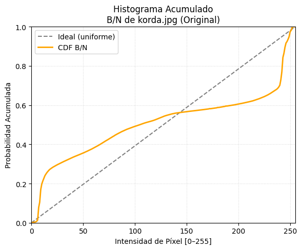

[figure not shown]

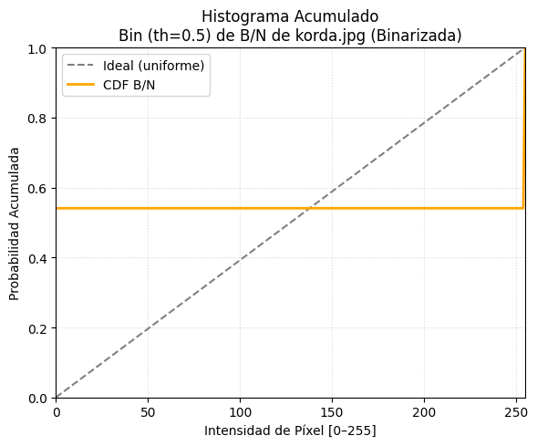

```python
imagen_korda = load_image("korda")
korda_gris = imagen_korda.escala_grises()
korda_gris.mostrar(block=False)
korda_gris.histograma(block=False)
korda_gris.graficar_acumulado("Original", block=False)

korda_binaria = korda_gris.binarizar(0.5)
korda_binaria.graficar_acumulado("Binarizada", block=False)
korda_binaria.histograma(block=False)

plt.show()
```

### Explicaciones del Ejercicio 8

**Descripción:** Se toma la fotografía de Ernesto Guevara (Korda), se convierte a escala de grises para unificar los canales y se aplica una binarización con umbral en 0.5, es decir, en el punto medio de los valores de píxel. Todo lo que está por arriba de $\frac{255}{2} \approx 127$ se pasa a blanco (255) y lo que está por debajo se pasa a negro (0).

**¿Qué algoritmo de binarización elegiste y por qué?**

El binarizado global tradicional, que simplemente separa los píxeles en blanco o negro según un umbral fijo. No se consideró necesario aplicar algún método más elaborado como una transformación T o lineal, ya que el binarizado simple da un muy buen resultado. Existen otros tipos de binarizado (adaptativo, Otsu, etc.), pero para lo que es una impresión en camiseta por serigrafía no se necesita mucha más definición y este funciona muy bien.

**¿Cuál es la proporción blanco/negro obtenida?**

No es exactamente 50-50 como recomienda el impresor, es un poco desproporcional. Hay una mayor cantidad de píxeles negros. Lograr un 50-50 exacto es difícil por la distribución natural de píxeles en la imagen. Sin embargo, el resultado es bastante aceptable.

El histograma de la imagen binarizada muestra algo curioso pero esperado: los píxeles se acumulan solo en 0 y en 255, sin nada en medio. Y el histograma acumulado da un salto justo a la mitad, lo cual confirma que el umbral está partiendo la imagen en ese punto.

**¿Cuáles fueron los criterios utilizados para tomar las decisiones de procesamiento?**

Básicamente la sencillez. Se obtiene un muy buen resultado con el menor esfuerzo posible. Se podría haber ajustado manualmente una transformación T o aplicar otro tipo de binarizado para afinar la proporción, pero para una impresión en camiseta el binarizado global funciona perfectamente.

## Conclusiones

La **ganancia digital** es la mas simple de todas: multiplica todos los pixeles por un factor constante. Funciona bien cuando se necesita un ajuste rapido de brillo, pero su limitacion es que afecta a todos los pixeles por igual, lo que puede saturar las zonas claras si se sube demasiado (como se vio en el ejercicio 4 con la tumba).

La **transformacion gamma** es mas versatil. Con $\gamma < 1$ se aclaran zonas oscuras y con $\gamma > 1$ se resaltan diferencias en zonas claras. Es una buena opcion general porque no requiere definir puntos a mano y da resultados parejos. Fue util en casi todos los ejercicios.

La **transformacion lineal por tramos** es la mas artesanal: permite atacar zonas especificas del histograma definiendo puntos de entrada y salida. Da muy buenos resultados cuando se sabe exactamente donde estan los pixeles que se quieren mover (como en el ejercicio 1c y 5), pero requiere analizar el histograma y ajustar los valores manualmente.

La **ecualizacion de histograma** fuerza una distribucion uniforme de los pixeles. En blanco y negro funciona muy bien y da resultados que se sienten naturales. Sin embargo, en color tiene un problema serio: al ecualizar cada canal RGB de manera independiente, se pierde el balance de color original y los tonos se distorsionan. Una alternativa seria trabajar sobre el canal de luminancia en vez de los canales de color directamente.

El **negativo** es util para invertir el contraste, como cuando se necesita ver tejidos blandos en una radiografia que fue tomada para ver huesos.

El **falso color** mediante remapeo por canal permite visualizar informacion que de otra forma seria dificil de interpretar, como en imagenes infrarrojas. Su definicion es principalmente a prueba y error, y usar imagenes de prueba (como cuadros de grises) facilita mucho el proceso.

En general, el histograma es la herramienta clave para decidir que transformacion aplicar: primero se observa donde se concentran los pixeles y con base en eso se elige la tecnica adecuada.